# Bratwurst

Sebastian Steinhauser & Daniel Huebschmann

20.07.2016

# Contents

```r
library(BiocStyle)
library(knitr)
library(ComplexHeatmap)
```

# 1 Introduction

**NMF** (**nonnegative matrix factorization**) is a matrix decomposition method. A description of the algorithm and it’s implementation can be found e.g. in (Lee and Seung 1999). In 2003, Brunet et al. applied NMF to gene expression data (Brunet et al. 2003). In 2010, *[NMF](http://cran.fhcrc.org/web/packages/NMF/index.html)*, an R package implementing several NMF solvers was published (Gaujoux and Seoighe 2010). NMF basically solves the problem as illustrated in the following figure (Image taken from https://en.wikipedia.org/wiki/Non-negative_matrix_factorization):

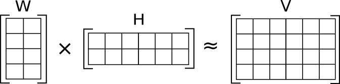

In 2015, Mejia-Roa et al. introduced an implementation of an NMF-solver in CUDA, which lead to significant reduction of computation times by making use of massive parallelisation on GPUs (Mejia-Roa et al. 2015). Other implementations of NMF-solvers on GPUs exist.

It is the pupose of the package `Bratwurst` described here to provide wrapper functions in R to these NMF-solvers in CUDA. Massive parallelisation not only leads to faster algorithms, but also makes the benefits of NMF accessible to much bigger matrices. Furthermore, functions for preprocessing, estimation of the optimal factorization rank and post-hoc feature selection are provided.

# 2 The Bratwurst package

The main feature of the package `Bratwurst` is an S4 object called `nmf.exp`. It is derived from `SummarizedExperiment`, has containers for a data matrix, column annotation data and row annotation data and inherits `SummarizedExperiment`’s accessor functions `colData` and `rowData`. The matrix to be stored in this data structure is the matrix $V$ as described above, corresponding to the input matrix for the NMF-solver. `nmf.exp` furthermore has containers for the matrices $W$ and $H$ which are results of the decomposition. As NMF algorithms have to be run iteratively, an instance of the class `nmf.exp` can store large lists of matrices, corresponding to the results of different iteration steps. Accessor functions to all different containers are provided.

A crucial step in data analysis with NMF is the determination of the optimal factorization rank, i.e. the number of columns of the matrix $W$ or equivalently the number of rows of the matrix $H$. No consensus method for an automatic evaluation of the optimal factorization rank has been found to date. Instead, the decomposition is usually performed iteratively over a range of possible factorization ranks and different quality measures are computed for every tested factorization ranks. Many quality measures have been proposed:

- The `Frobenius reconstruction error`, i.e. the Frobenius norm of the residuals of the decomposition: $||W \cdot H - V||_{F}$
- Criteria to assess the stability of the decomposition:
- The `cophenetic correlation coefficient`
- An `Amari type distance`
- `Silhouette values` over clusters of patterns extracted iteratively at the same factorization rank

# 3 Example: leukemia data

Preparations

```r
library(Bratwurst)
```

Load the example data

```r
data(leukemia)
samples <- 'leukemia'
```

This data was initially generated by the following commands:

```r
#result.path <- './home/thymin'
data.path  <- file.path(getwd(), 'data')
matrix.file <- list.files(data.path, 'data.txt', full.names = T)
rowAnno.file <- list.files(data.path, 'micro.*anno.*txt', full.names = T)
rowAnno.bed <- list.files(data.path, '.bed', full.names = T)
colAnno.file <- list.files(data.path, 'sample.*anno.*txt', full.names = T)
# Read files to summarizedExperiment
leukemia.nmf.exp <- nmfExperimentFromFile(matrix.file = matrix.file,
                                          rowAnno.file = rowAnno.file,
                                          colData.file = colAnno.file)
save(leukemia.nmf.exp, file = file.path(data.path,"leukemia.rda"))
```

Now we are ready to start an NMF analysis.

## 3.1 NMF analysis

### 3.1.1 Call wrapper function

The wrapper function for the NMF solvers in the Bratwurst package is `runNmfGpu`. It is called as follows:

```r
k.max <- 4
outer.iter <- 10
inner.iter <- 10^4

leukemia.nmf.exp<- runNmfGpu(nmf.exp = leukemia.nmf.exp,
                             k.max = k.max,
                             outer.iter = outer.iter,
                             inner.iter = inner.iter,
                             tmp.path = "/tmp/tmp_leukemia")
```

```
## [1] "2016-08-27 21:18:08 CEST"
## Factorization rank:  2
##  Iteration:  10
## [1] "2016-08-27 21:18:13 CEST"
## Factorization rank:  3
##  Iteration:  10
## [1] "2016-08-27 21:18:19 CEST"
## Factorization rank:  4
##  Iteration:  10
```

Depending on the choice of parameters (dimensions of the input matrix, number of iterations), this step may take some time. Note that the algorithm updates the user about the progress in the iterations.

Several getter functions are available to access the data in the updated `nmf.exp` object:

### 3.1.2 `HMatrixList`

Returns a list of matrices `H` for a specific factorization rank `k`. There are as many entries in this list as there were iterations in the outer iteration. Of course the number of rows of the matrix `H` corresponds to the chosen factorization rank.

```r
tmp.object <- HMatrixList(leukemia.nmf.exp, k = 2)
class(tmp.object)
```

```
## [1] "list"
```

```r
length(tmp.object)
```

```
## [1] 10
```

```r
class(tmp.object[[1]])
```

```
## [1] "matrix"
```

```r
dim(tmp.object[[1]])
```

```
## [1]  2 38
```

```r
kable(tmp.object[[1]][,c(1:5)])
```

| V1 | V2 | V3 | V4 | V5 |
| --- | --- | --- | --- | --- |
| 617.8400 | 566.2250 | 613.341 | 552.6600 | 482.682 |
| 75.0693 | 43.4671 | 106.663 | 61.1598 | 140.991 |

If no value for `k` is supplied, the function returns a list of lists, one for every iterated factorization rank.

```r
tmp.object <- HMatrixList(leukemia.nmf.exp)
class(tmp.object)
```

```
## [1] "list"
```

```r
length(tmp.object)
```

```
## [1] 3
```

```r
class(tmp.object[[1]])
```

```
## [1] "list"
```

```r
length(tmp.object[[1]])
```

```
## [1] 10
```

### 3.1.3 `HMatrix`

Returns the matrix `H` for the optimal decomposition (i.e. the one with the minimal residual) for a specific factorization rank `k`. As in the previous paragraph, the number of rows of the matrix `H` corresponds to the chosen factorization rank.

```r
tmp.object <- HMatrix(leukemia.nmf.exp, k = 2)
class(tmp.object)
```

```
## [1] "matrix"
```

```r
dim(tmp.object)
```

```
## [1]  2 38
```

```r
kable(tmp.object[,c(1:5)])
```

| V1 | V2 | V3 | V4 | V5 |
| --- | --- | --- | --- | --- |
| 604.6900 | 554.1640 | 600.216 | 540.9110 | 472.416 |
| 75.9642 | 43.8563 | 108.233 | 61.8304 | 143.128 |

If no value for `k` is supplied, the function returns a list of optimal matrices, one for every iterated factorization rank.

```r
H.list <- HMatrix(leukemia.nmf.exp)
class(H.list)
```

```
## [1] "list"
```

```r
length(H.list)
```

```
## [1] 3
```

```r
kable(H.list[[1]][,c(1:5)])
```

| V1 | V2 | V3 | V4 | V5 |
| --- | --- | --- | --- | --- |
| 604.6900 | 554.1640 | 600.216 | 540.9110 | 472.416 |
| 75.9642 | 43.8563 | 108.233 | 61.8304 | 143.128 |

### 3.1.4 `WMatrixList`

Returns a list of matrices `W` for a specific factorization rank `k`. There are as many entries in this list as there were iterations in the outer iteration. Of course the number of columns of the matrix `W` corresponds to the chosen factorization rank.

```r
tmp.object <- WMatrixList(leukemia.nmf.exp, k = 2)
class(tmp.object)
```

```
## [1] "list"
```

```r
length(tmp.object)
```

```
## [1] 10
```

```r
class(tmp.object[[1]])
```

```
## [1] "matrix"
```

```r
dim(tmp.object[[1]])
```

```
## [1] 4951    2
```

```r
kable(tmp.object[[1]][c(1:5),])
```

| V1 | V2 |
| --- | --- |
| 0.4049620 | 0.2887860 |
| 0.0855878 | 0.0219128 |
| 0.4474670 | 0.3493620 |
| 0.0643233 | 0.0431426 |
| 0.0893303 | 0.0658753 |

If no value for `k` is supplied, the function returns a list of lists, one for every iterated factorization rank.

### 3.1.5 `WMatrix`

Returns the matrix `W` for the optimal decomposition (i.e. the one with the minimal residual) for a specific factorization rank `k`. As in the previous paragraph, the number of columns of the matrix `W` corresponds to the chosen factorization rank.

```r
tmp.object <- WMatrix(leukemia.nmf.exp, k = 2)
class(tmp.object)
```

```
## [1] "matrix"
```

```r
dim(tmp.object)
```

```
## [1] 4951    2
```

```r
kable(tmp.object[c(1:5),])
```

| V1 | V2 |
| --- | --- |
| 0.4139880 | 0.2837580 |
| 0.0874692 | 0.0215289 |
| 0.4574180 | 0.3433390 |
| 0.0657540 | 0.0423929 |
| 0.0913194 | 0.0647331 |

If no value for `k` is supplied, the function returns a list of optimal matrices, one for every iterated factorization rank.

```r
W.list <- WMatrix(leukemia.nmf.exp)
class(W.list)
```

```
## [1] "list"
```

```r
length(W.list)
```

```
## [1] 3
```

```r
kable(W.list[[1]][c(1:5),])
```

| V1 | V2 |
| --- | --- |
| 0.4139880 | 0.2837580 |
| 0.0874692 | 0.0215289 |
| 0.4574180 | 0.3433390 |
| 0.0657540 | 0.0423929 |
| 0.0913194 | 0.0647331 |

### 3.1.6 `FrobError`

Returns a data frame with as many columns as there are iterated factorization ranks and as many rows as there are iterations per factorization rank.

```r
kable(FrobError(leukemia.nmf.exp))
```

| 2 | 3 | 4 |
| --- | --- | --- |
| 0.558340 | 0.513969 | 0.464344 |
| 0.558340 | 0.513965 | 0.464193 |
| 0.558347 | 0.513968 | 0.464704 |
| 0.558348 | 0.513974 | 0.464256 |
| 0.558346 | 0.513967 | 0.464339 |
| 0.558346 | 0.513971 | 0.466074 |
| 0.558347 | 0.513971 | 0.464335 |
| 0.558339 | 0.513968 | 0.464535 |
| 0.558339 | 0.513965 | 0.464513 |
| 0.558343 | 0.513970 | 0.494640 |

## 3.2 Determine the optimal factorization rank

In NMF, Several methods have been described to assess the optimal factorization rank. The Bratwurst packages implements some of them. They are computed by applying custom functions which subsequently update the data structure of type `nmf.exp`.

### 3.2.1 Get Frobenius error.

The most important information about the many iterated decompositions is the norm of the residual. In NMF this is often called the Frobenius error, as the Frobenius norm may be used.

```r
leukemia.nmf.exp <- computeFrobErrorStats(leukemia.nmf.exp)
```

### 3.2.2 Generate Alexandrov Criterion plot

In (Alexandrov et al. 2013) an approach is described in which a modified silhouette criterion is used to estimate the stability across iteration steps for one fixed factorization rank `k`.

```r
leukemia.nmf.exp <- computeSilhoutteWidth(leukemia.nmf.exp)
```

### 3.2.3 Cophenetic correlation coefficient plot

```r
leukemia.nmf.exp <- computeCopheneticCoeff(leukemia.nmf.exp)
```

### 3.2.4 Compute amari type distance

```r
leukemia.nmf.exp <- computeAmariDistances(leukemia.nmf.exp)
```

After having executed all these functions, the values of the computed measures can be accessed with `OptKStats`:

```r
kable(OptKStats(leukemia.nmf.exp))
```

|  | k | min | mean | sd | cv | sumSilWidth | meanSilWidth | copheneticCoeff | meanAmariDist |
| --- | --- | --- | --- | --- | --- | --- | --- | --- | --- |
| 2 | 2 | 0.558339 | 0.5583435 | 0.0000037 | 0.0000066 | 19.99998 | 0.9999989 | 0.9999989 | 0.0000004 |
| 3 | 3 | 0.513965 | 0.5139688 | 0.0000028 | 0.0000055 | 29.99995 | 0.9999984 | 0.9617061 | 0.0000005 |
| 4 | 4 | 0.464193 | 0.4675933 | 0.0095189 | 0.0203572 | 37.76855 | 0.9442138 | 0.9612176 | 0.0207956 |

These quality measures can be displayed together:

### 3.2.5 Generate plots to estimate optimal k

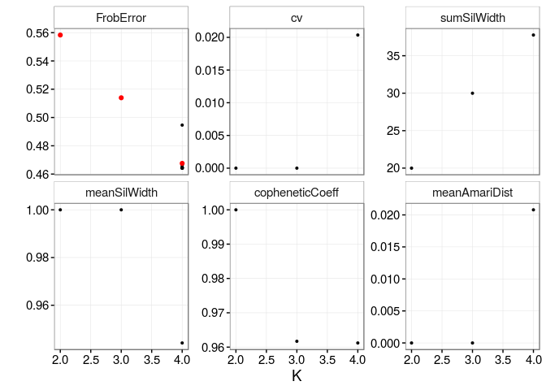

```r
gg.optK <- plotKStats(leukemia.nmf.exp)
gg.optK
```

### 3.2.6 Generate ranked error plot.

It may also be useful to inspect the Frobenius error after ranking. This may give an estimation of the convergence in the parameter space of initial conditions.

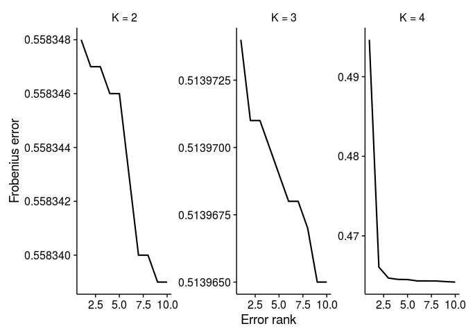

```r
gg.rankedFrobError <- plotRankedFrobErrors(leukemia.nmf.exp)
gg.rankedFrobError
```

## 3.3 Visualize the matrix H (exposures)

The matrices `H` may be visualized as heatmaps. We can define a meta information object and annotate meta data:

```r
entity.colVector <- c("red", "blue")
names(entity.colVector) <- c("ALL","AML")
subtype.colVector <- c("orange", "darkgreen", "blue")
names(subtype.colVector) <- c("B-cell", "T-cell", "-")
anno_col <- list(V2 = entity.colVector,
                 V3 = subtype.colVector)
heat.anno <- HeatmapAnnotation(df = colData(leukemia.nmf.exp)[,c(2:3)],
                               col = anno_col)
```

And now display the matrices `H` with meta data annotation:

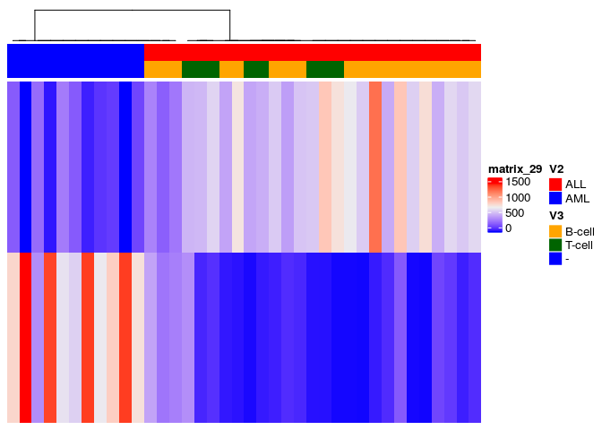

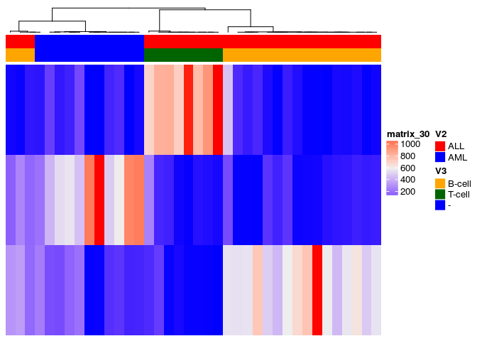

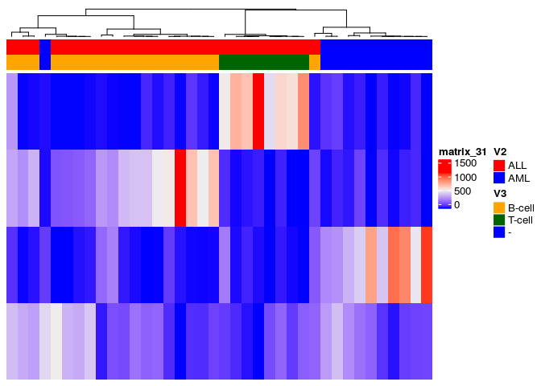

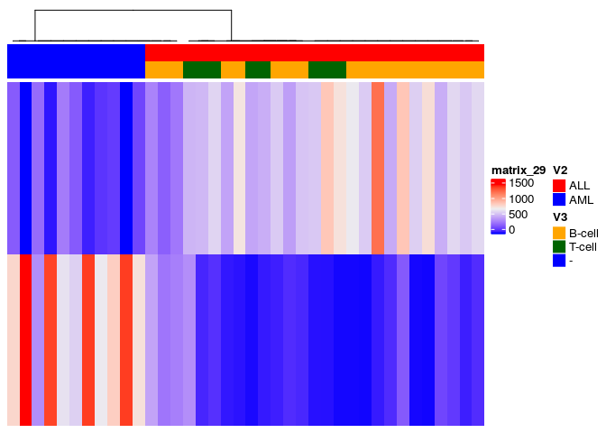

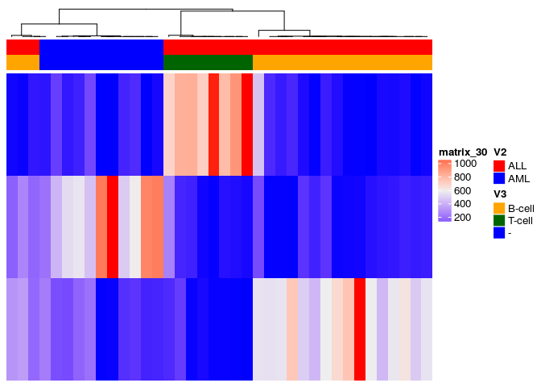

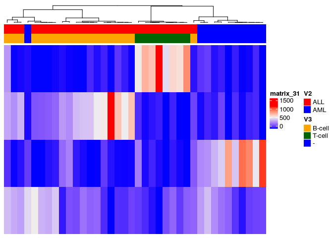

```r
sapply(1:length(HMatrix(leukemia.nmf.exp)), function(i) {
  current_k <- as.numeric(names(HMatrix(leukemia.nmf.exp))[i])
  h.heatmap <- Heatmap(HMatrix(leukemia.nmf.exp, k = current_k),
                       clustering_distance_columns = 'pearson',
                       heatmap_legend_param = list(color_bar = "continuous"),
                       show_column_names = F, cluster_rows = F,
                       top_annotation = heat.anno)
  draw(h.heatmap)
})
```

References

Alexandrov, LB, S Nik-Zainal, DC Wedge, SA Aparicio, S Behjati, AV Biankin, GR Bignell, et al. 2013. “Signatures of Mutational Processes in Cancer.” *Nature*. Nature Publishing Group.

Brunet, Jean-Philippe, Pablo Tamayo, Todd R. Golub, and Jill P. Mesirov. 2003. “Metagenes and Molecular Pattern Discovery Using Matrix Factorization.” *PNAS*. PNAS.

Gaujoux, Renaud, and Cathal Seoighe. 2010. “A Flexible R Package for Nonnegative Matrix Factorization.” *BMC Bioinformatics*. BMC.

Lee, Daniel D., and Sebastian Seung. 1999. “Learning the Parts of Objects by Non-Negative Matrix Factorization.” *Nature*. Nature Publishing Group.

Mejia-Roa, Edgardo, Daniel Tabas-Madrid, Javier Setoain, Carlos Garcia, Francisco Tirado, and Alberto Pascual-Montano. 2015. “NMF-MGPU: Non-Negative Matrix Factorization on Multi-GPU Systems.” *BMC Bioinformatics*. BMC.